# Machine Learning: Course Project

Jeremy Peters

February 5, 2018

### Executive Summary

Using devices such as Jawbone Up, Nike FuelBand, and Fitbit it is now possible to collect a large amount of data about personal activity relatively inexpensively. In a study, Six young health participants were asked to perform one set of 10 repetitions of the Unilateral Dumbbell Biceps Curl in five different fashions: exactly according to the specification (Class A), throwing the elbows to the front (Class B), lifting the dumbbell only halfway (Class C), lowering the dumbbell only halfway (Class D) and throwing the hips to the front (Class E).Only Class A corresponds to correct performance. The objective of this project is to use data from accelerometers on the belt, forearm, arm, and dumbell of 6 participants to build a machine learning algorithm to predict the manner/class type in which an exerise was completed. More information about the study and data set can be found in the section on the Weight Lifting Exercise Dataset at the following URL: http://groupware.les.inf.puc-rio.br/har.

### Exploratory Data Analysis

- The training data for this project was download from the following URL: https://d396qusza40orc.cloudfront.net/predmachlearn/pml-training.csv
- The test data for this project was download from the following URL: https://d396qusza40orc.cloudfront.net/predmachlearn/pml-testing.csv
- Load the required r packages: caret, gbm and randomForest
- Read the Training and Testing CSV files in table format, specify types of missing values (NA, empty strings and div0), and create data frames
- Display the internal structure of an R object and generate summary statistics of the training dataset
- The Training dataset contains 160 variables and 19,622 records
- The Testing dataset contains 160 variables and 20 records
- classe is the outcome factor variable with 5 levels: Class A, Class B, Class C, Class D, and Class E

```r
# Load the required r packages
library(caret)
library(randomForest)
library(gbm)
dfTrain <- read.csv("pml-training.csv", header = TRUE, na.strings=c("NA","#DIV/0!",""))
dfTest <- read.csv("pml-testing.csv", header = TRUE, na.strings=c("NA","#DIV/0!",""))

# Get variable names
names(dfTrain)
```

```
##   [1] "X"                        "user_name"
##   [3] "raw_timestamp_part_1"     "raw_timestamp_part_2"
##   [5] "cvtd_timestamp"           "new_window"
##   [7] "num_window"               "roll_belt"
##   [9] "pitch_belt"               "yaw_belt"
##  [11] "total_accel_belt"         "kurtosis_roll_belt"
##  [13] "kurtosis_picth_belt"      "kurtosis_yaw_belt"
##  [15] "skewness_roll_belt"       "skewness_roll_belt.1"
##  [17] "skewness_yaw_belt"        "max_roll_belt"
##  [19] "max_picth_belt"           "max_yaw_belt"
##  [21] "min_roll_belt"            "min_pitch_belt"
##  [23] "min_yaw_belt"             "amplitude_roll_belt"
##  [25] "amplitude_pitch_belt"     "amplitude_yaw_belt"
##  [27] "var_total_accel_belt"     "avg_roll_belt"
##  [29] "stddev_roll_belt"         "var_roll_belt"
```

[output cut: 65 more lines]

```r
str(dfTrain)
```

```
## 'data.frame':    19622 obs. of  160 variables:
##  $ X                       : int  1 2 3 4 5 6 7 8 9 10 ...
##  $ user_name               : Factor w/ 6 levels "adelmo","carlitos",..: 2 2 2 2 2 2 2 2 2 2 ...
##  $ raw_timestamp_part_1    : int  1323084231 1323084231 1323084231 1323084232 1323084232 1323084232 1323084232 1323084232 1323084232 1323084232 ...
##  $ raw_timestamp_part_2    : int  788290 808298 820366 120339 196328 304277 368296 440390 484323 484434 ...
##  $ cvtd_timestamp          : Factor w/ 20 levels "02/12/2011 13:32",..: 9 9 9 9 9 9 9 9 9 9 ...
##  $ new_window              : Factor w/ 2 levels "no","yes": 1 1 1 1 1 1 1 1 1 1 ...
##  $ num_window              : int  11 11 11 12 12 12 12 12 12 12 ...
##  $ roll_belt               : num  1.41 1.41 1.42 1.48 1.48 1.45 1.42 1.42 1.43 1.45 ...
##  $ pitch_belt              : num  8.07 8.07 8.07 8.05 8.07 8.06 8.09 8.13 8.16 8.17 ...
##  $ yaw_belt                : num  -94.4 -94.4 -94.4 -94.4 -94.4 -94.4 -94.4 -94.4 -94.4 -94.4 ...
##  $ total_accel_belt        : int  3 3 3 3 3 3 3 3 3 3 ...
##  $ kurtosis_roll_belt      : num  NA NA NA NA NA NA NA NA NA NA ...
##  $ kurtosis_picth_belt     : num  NA NA NA NA NA NA NA NA NA NA ...
##  $ kurtosis_yaw_belt       : logi  NA NA NA NA NA NA ...
```

[output cut: 86 more lines]

```r
dim(dfTest)
```

```
## [1]  20 160
```

```r
#summary(dfTrain)
summary(dfTrain$classe)
```

```
##    A    B    C    D    E
## 5580 3797 3422 3216 3607
```

### Data Processing: Cleaning and Preparation

- Remove the first seven descriptive variables/fields (X/Id, user_name,raw_timestamp_part_1, raw_timestamp_part_2, cvtd_timestamp, new_window, num_window) from both data sets that will not help predict the manner in which an exercise was completed.
- Remove the variables/fields from the data set that contain missing values
- Remove Near Zero Variance Variables
- The resulting Training and Testing datasets both have 53 variables/fields the last of which is the classe variable/field
- Cross-validation is performed by splitting the cleaned training data set into a training data set (75%) that will be used for prediction and a testing/validation data set (25%) that will be used to determine out-of-sample errors

```r
dfTrain <- dfTrain[, -c(1:7)]
dfTest <- dfTest[, -c(1:7)]


dfTrain <- dfTrain[, colSums(is.na(dfTrain)) == 0]
dfTest <- dfTest[, colSums(is.na(dfTest)) == 0]

#Remove any Near Zero Variance Variables
nzVar <- nearZeroVar(dfTrain, saveMetrics = TRUE)
nzVar
```

```
##                      freqRatio percentUnique zeroVar   nzv
## roll_belt             1.101904     6.7781062   FALSE FALSE
## pitch_belt            1.036082     9.3772296   FALSE FALSE
## yaw_belt              1.058480     9.9734991   FALSE FALSE
## total_accel_belt      1.063160     0.1477933   FALSE FALSE
## gyros_belt_x          1.058651     0.7134849   FALSE FALSE
## gyros_belt_y          1.144000     0.3516461   FALSE FALSE
## gyros_belt_z          1.066214     0.8612782   FALSE FALSE
## accel_belt_x          1.055412     0.8357966   FALSE FALSE
## accel_belt_y          1.113725     0.7287738   FALSE FALSE
## accel_belt_z          1.078767     1.5237998   FALSE FALSE
## magnet_belt_x         1.090141     1.6664968   FALSE FALSE
## magnet_belt_y         1.099688     1.5187035   FALSE FALSE
## magnet_belt_z         1.006369     2.3290184   FALSE FALSE
## roll_arm             52.338462    13.5256345   FALSE FALSE
## pitch_arm            87.256410    15.7323412   FALSE FALSE
## yaw_arm              33.029126    14.6570176   FALSE FALSE
## total_accel_arm       1.024526     0.3363572   FALSE FALSE
## gyros_arm_x           1.015504     3.2769341   FALSE FALSE
## gyros_arm_y           1.454369     1.9162165   FALSE FALSE
## gyros_arm_z           1.110687     1.2638875   FALSE FALSE
## accel_arm_x           1.017341     3.9598410   FALSE FALSE
## accel_arm_y           1.140187     2.7367241   FALSE FALSE
## accel_arm_z           1.128000     4.0362858   FALSE FALSE
## magnet_arm_x          1.000000     6.8239731   FALSE FALSE
## magnet_arm_y          1.056818     4.4439914   FALSE FALSE
## magnet_arm_z          1.036364     6.4468454   FALSE FALSE
## roll_dumbbell         1.022388    84.2065029   FALSE FALSE
## pitch_dumbbell        2.277372    81.7449801   FALSE FALSE
## yaw_dumbbell          1.132231    83.4828254   FALSE FALSE
## total_accel_dumbbell  1.072634     0.2191418   FALSE FALSE
## gyros_dumbbell_x      1.003268     1.2282132   FALSE FALSE
## gyros_dumbbell_y      1.264957     1.4167771   FALSE FALSE
## gyros_dumbbell_z      1.060100     1.0498420   FALSE FALSE
## accel_dumbbell_x      1.018018     2.1659362   FALSE FALSE
## accel_dumbbell_y      1.053061     2.3748853   FALSE FALSE
## accel_dumbbell_z      1.133333     2.0894914   FALSE FALSE
## magnet_dumbbell_x     1.098266     5.7486495   FALSE FALSE
## magnet_dumbbell_y     1.197740     4.3012945   FALSE FALSE
## magnet_dumbbell_z     1.020833     3.4451126   FALSE FALSE
## roll_forearm         11.589286    11.0895933   FALSE FALSE
## pitch_forearm        65.983051    14.8557741   FALSE FALSE
## yaw_forearm          15.322835    10.1467740   FALSE FALSE
## total_accel_forearm   1.128928     0.3567424   FALSE FALSE
## gyros_forearm_x       1.059273     1.5187035   FALSE FALSE
## gyros_forearm_y       1.036554     3.7763735   FALSE FALSE
## gyros_forearm_z       1.122917     1.5645704   FALSE FALSE
## accel_forearm_x       1.126437     4.0464784   FALSE FALSE
## accel_forearm_y       1.059406     5.1116094   FALSE FALSE
## accel_forearm_z       1.006250     2.9558659   FALSE FALSE
## magnet_forearm_x      1.012346     7.7667924   FALSE FALSE
## magnet_forearm_y      1.246914     9.5403119   FALSE FALSE
## magnet_forearm_z      1.000000     8.5771073   FALSE FALSE
## classe                1.469581     0.0254816   FALSE FALSE
```

```r
dfTrain <- dfTrain[, !nzVar$nzv]
dfTest <- dfTest[, !nzVar$nzv]
dim(dfTrain)
```

```
## [1] 19622    53
```

```r
dfInTrain <- createDataPartition(dfTrain$classe, p = 0.75, list = FALSE)
dfPredict <- dfTrain[dfInTrain, ]
dfValidate <- dfTrain[-dfInTrain, ]
```

### Model Fitting

```r
set.seed(25)

#fitControl <- trainControl(method='cv', number = 10)
#modFitRf<- train(classe ~ ., data = dfPredict, method = "rf", trControl = fitControl)
modFitRf<- train(classe ~ ., data = dfPredict, method = "rf")
modFitRf
```

```
## Random Forest
##
## 14718 samples
##    52 predictor
##     5 classes: 'A', 'B', 'C', 'D', 'E'
##
## No pre-processing
## Resampling: Bootstrapped (25 reps)
## Summary of sample sizes: 14718, 14718, 14718, 14718, 14718, 14718, ...
## Resampling results across tuning parameters:
##
##   mtry  Accuracy   Kappa
##    2    0.9906794  0.9882046
##   27    0.9900871  0.9874556
##   52    0.9820215  0.9772476
##
## Accuracy was used to select the optimal model using the largest value.
## The final value used for the model was mtry = 2.
```

```r
predictRf <- predict(modFitRf, dfValidate)
confusionMatrix(dfValidate$classe, predictRf)
```

```
## Confusion Matrix and Statistics
##
##           Reference
## Prediction    A    B    C    D    E
##          A 1394    1    0    0    0
##          B   11  937    1    0    0
##          C    0   11  842    2    0
##          D    0    0   10  794    0
##          E    0    0    1    2  898
##
## Overall Statistics
##
##                Accuracy : 0.992
##                  95% CI : (0.9891, 0.9943)
##     No Information Rate : 0.2865
##     P-Value [Acc > NIR] : < 2.2e-16
##
##                   Kappa : 0.9899
##  Mcnemar's Test P-Value : NA
##
## Statistics by Class:
##
##                      Class: A Class: B Class: C Class: D Class: E
## Sensitivity            0.9922   0.9874   0.9859   0.9950   1.0000
## Specificity            0.9997   0.9970   0.9968   0.9976   0.9993
## Pos Pred Value         0.9993   0.9874   0.9848   0.9876   0.9967
## Neg Pred Value         0.9969   0.9970   0.9970   0.9990   1.0000
## Prevalence             0.2865   0.1935   0.1741   0.1627   0.1831
## Detection Rate         0.2843   0.1911   0.1717   0.1619   0.1831
## Detection Prevalence   0.2845   0.1935   0.1743   0.1639   0.1837
## Balanced Accuracy      0.9959   0.9922   0.9914   0.9963   0.9996
```

```r
accuracy1 <- postResample(predictRf, dfValidate$classe)
accuracy1
```

```
##  Accuracy     Kappa
## 0.9920473 0.9899380
```

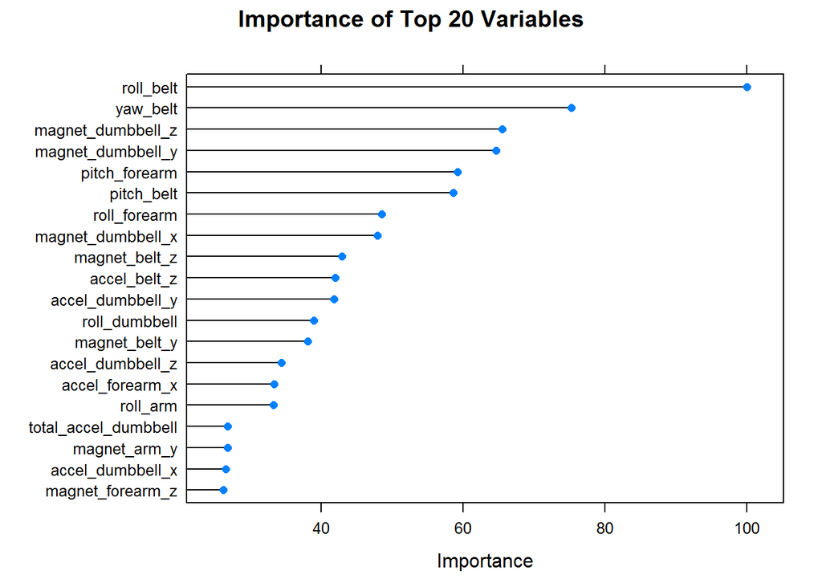

```r
#Calculate the variable importance
modFitRfvarImp <- varImp(modFitRf)
plot(modFitRfvarImp, main = "Importance of Top 20 Variables", top = 20)
```

### Conclusions & Test Data Set Prediction

- The Random Forest algorithm performed very well and gave the best result with an accuracy of 0.992 where accuracy is the proportion of correctly classified observations in the cross-validation test data set. The expected out-of-sample error rate is estimated at 0.008 (1 - accuracy) to represent the the expected misclassified observations in the test data set.
- Therefore, the Random Forest predictive model is applied to the 20 test cases available in the origninal test data set (not cross-validation test data set) . We can expected that few of the test samples will be misclassified based on the accuracy shown on the cross-validation data set.
- 1 2 3 4 5 6 7 8 9 10 11 12 13 14 15 16 17 18 19 20
- B A B A A E D B A A B C B A E E A B B B

```r
predictRf <- predict(modFitRf, dfTest)
predictRf
```

```
##  [1] B A B A A E D B A A B C B A E E A B B B
## Levels: A B C D E
```

### Appendix

- Stochastic Gradient Boosting Predictive models is fitted to predict the manner/class type in which an exerise was completed
- The results are predicted using the validation data set
- The results are compared using a confusionMatrix: a cross-tabulation of observed and predicted classes with associated statistics.
- The accuracy/overall agreement rate and Kappa are computed

```r
modFitGbm<- train(classe ~ ., data = dfPredict, method = "gbm")
predictGbm <- predict(modFitGbm, dfValidate)
confusionMatrix(dfValidate$classe, predictGbm)
```

```
## Confusion Matrix and Statistics
##
##           Reference
## Prediction    A    B    C    D    E
##          A 1378   12    4    0    1
##          B   29  899   19    2    0
##          C    0   28  814   10    3
##          D    0    0   31  769    4
##          E    0   16    8   12  865
##
## Overall Statistics
##
##                Accuracy : 0.9635
##                  95% CI : (0.9579, 0.9686)
##     No Information Rate : 0.2869
##     P-Value [Acc > NIR] : < 2.2e-16
##
##                   Kappa : 0.9538
##  Mcnemar's Test P-Value : NA
##
## Statistics by Class:
##
##                      Class: A Class: B Class: C Class: D Class: E
## Sensitivity            0.9794   0.9414   0.9292   0.9697   0.9908
## Specificity            0.9951   0.9873   0.9898   0.9915   0.9911
## Pos Pred Value         0.9878   0.9473   0.9520   0.9565   0.9600
## Neg Pred Value         0.9917   0.9858   0.9847   0.9941   0.9980
## Prevalence             0.2869   0.1947   0.1786   0.1617   0.1780
## Detection Rate         0.2810   0.1833   0.1660   0.1568   0.1764
## Detection Prevalence   0.2845   0.1935   0.1743   0.1639   0.1837
## Balanced Accuracy      0.9873   0.9643   0.9595   0.9806   0.9910
```

```r
accuracy2 <- postResample(predictGbm, dfValidate$classe)
accuracy2
```

```
##  Accuracy     Kappa
## 0.9634992 0.9538162
```